# Introduction to JPEG compression, monochrome case.

This tutorial covers the calculations related to JPEG compression including the Discrete Cosine Transform (dct), the dct coefficient quantization, and the inversion process.

## Contents

- JPEG compression of a grayscale image
- The image block
- The DCT properties
- Quantization
- JPEG decoding
- Decode the whole image
- Thought questions
- **AUTHOR**: X. Zhang, B. Wandell
- **PURPOSE**: Explain the basic features of JPEG compression
- **DATE**: 02.15.96
- **Matlab 5:** Checked 01.06.98, BW
- **Matlab 7**: Checked 01.02.08 BW.
- **Livescript** 2020.

```matlab
ieInit;
```

## JPEG compression of a grayscale image

Read in this monochrome picture to get started.

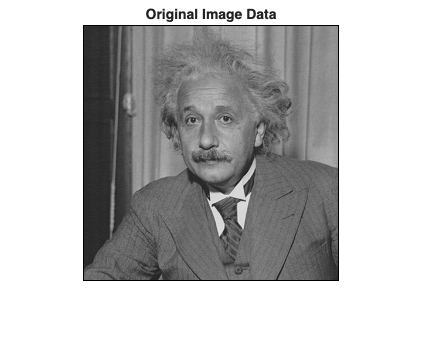

```matlab
load('einstein.mat','X');  % The image is stored in the variable X
im = X;

ieNewGraphWin;
imshow(im,[1,256]);
title('Original Image Data');
```

## The image block

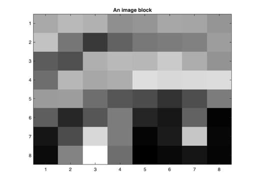

```matlab
block = im(89:96, 105:112);
ieNewGraphWin;
imagesc(block); colormap(gray); title('An image block')
```

And here is a histogram of the intensities in that block.

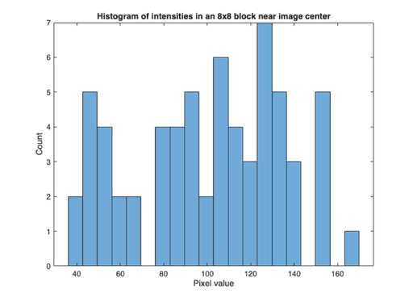

```matlab
ieNewGraphWin; histogram(block(:),20)
title('Histogram of intensities in an 8x8 block near image center');
xlabel('Pixel value');
ylabel('Count');
```

## The DCT properties

The DCT transform of the block multiplies the data by the functions of the DCT. I have stored these functions in a file that we load. To see how these functions are calculated read the code in

- jpegFiles/makeDctMatrix.m

Each row of this matrix is a cos function at a different spatial frequency. But they are very coarsely sampled and so they don't really look familiar.

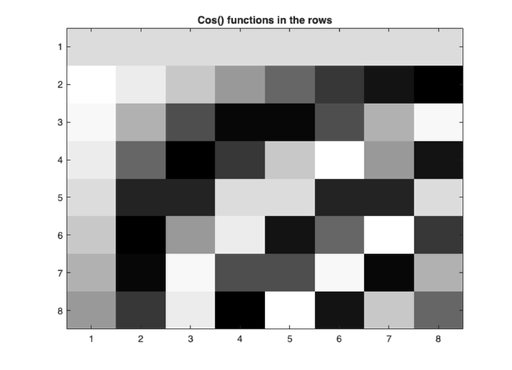

```matlab
load jpegFiles/dctMatrix;
ieNewGraphWin;
imagesc(dctMatrix); colormap(gray);
title('Cos() functions in the rows')
```

The DCT is an orthonormal matrix, so multiplying it by its own transpose is the identity

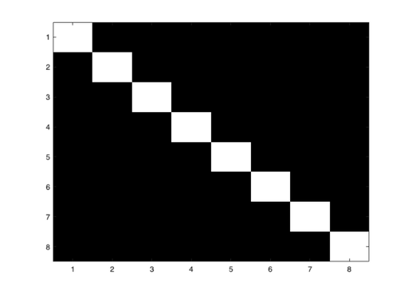

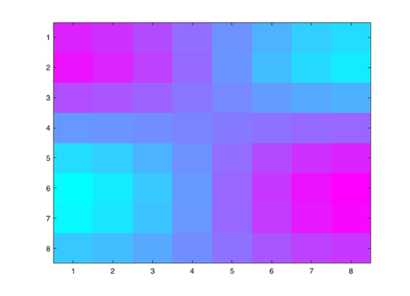

```matlab
ieNewGraphWin;
imagesc(dctMatrix*dctMatrix');
colormap(gray)
% Multiplying by the DCT matrix
% The DCT is separable - this means we multiply columns  by the dctMatrix and
% then we multiply the rows by the transpose of the matrix.  Consider the image
% when we multiply a row of the dctMatrix by a column

dctrow = dctMatrix(2,:);
dctcol = dctMatrix(:,2);
outerProd = dctcol*dctrow;
ieNewGraphWin; imagesc(outerProd);
colormap(cool);
```

```matlab
dctCoef = dctMatrix*block*dctMatrix';
```

Here is an image of the coefficients. We use a nonlinear map so that the appearance of the blocks will correspond a little better with their actual values. Gray values represent coefficients near zero. Bright values (upper left, the mean) are positive and black values are negative. Notice that the higher order coefficients (lower right) are small. They tend to be small in general.

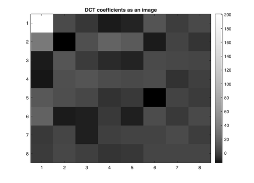

```matlab
ieNewGraphWin;
linMap = gray.^0.5;
imagesc(dctCoef); colormap(linMap);
colorbar;
title('DCT coefficients as an image')
```

Notice that the histogram of the coefficients is much more compressible than the histogram of the individual pixel intensities.

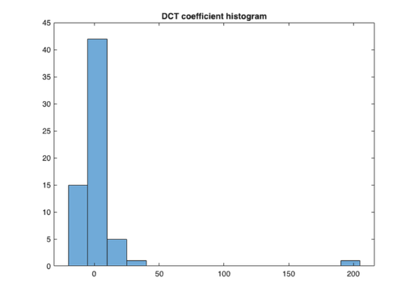

```matlab
ieNewGraphWin;
histogram(dctCoef(:),15)
title('DCT coefficient histogram')
% An aside
% An aside: If we use the DCT function in Matlab, the results are close to the
% same, except for some extra scaling and mis-matches at the low range that are
% required for the JPEG standard.

% c = [ 1/sqrt(2) 1 1 1 1 1 1 1 ];
% dctCoef1 = dct(block)'*diag(c)/8;      % apply dct on columns
% dctCoefm = dct(dctCoef1)'*diag(c)/8;   % apply dct on rows
%
% ieNewGraphWin;
% plot(dctCoefm(:),dctCoef(:))
% grid on;
```

## Quantization

There is a standard quantization table provided by JPEG of each of the quantization steps. The one that is hard coded into the C-code is returned when you set the quality factor equal to 50.

```matlab
Q_factor = 50;
q1 = jpeg_qtables(Q_factor,1);
disp(q1)
```

```
    16    11    12    14    12    10    16    14
    13    14    18    17    16    19    24    40
    26    24    22    22    24    49    35    37
    29    40    58    51    61    60    57    51
    56    55    64    72    92    78    64    68
    87    69    55    56    80   109    81    87
    95    98   103   104   103    62    77   113
   121   112   100   120    92   101   103    99
```

Big numbers in this table are places where the dct coefficients will be strongly quantized. Small numbers, at the low frequency coefficients, will not be quantized as much. Notice, that with this default everything is quantized a little. If we want a really high quality factor, look at what happens to the table. Compare it with the previous one.

```matlab
Q_factor = 90;
q1 = jpeg_qtables(Q_factor,1);
disp(q1)
```

```
     3     2     2     3     2     2     3     3
     3     3     4     3     3     4     5     8
     5     5     4     4     5    10     7     7
     6     8    12    10    12    12    11    10
    11    11    13    14    18    16    13    14
    17    14    11    11    16    22    16    17
    19    20    21    21    21    12    15    23
    24    22    20    24    18    20    21    20
```

To make the picture of the quantization table, I have set light colors to mean preserve the coefficient and black mean lose it

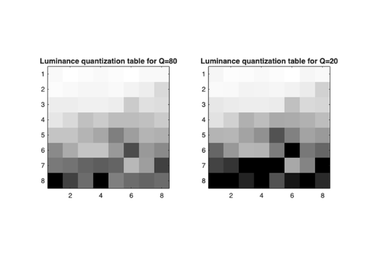

```matlab
colormap(linMap);

Q_factor = 80;
subplot(1,2,1); imagesc(256 -jpeg_qtables(Q_factor,1));
title(sprintf('Luminance quantization table for Q=%d',Q_factor));
axis image

Q_factor = 20;
subplot(1,2,2); imagesc(256 - jpeg_qtables(Q_factor,1));
title(sprintf('Luminance quantization table for Q=%d',Q_factor));
axis image
```

Now we use the quantization table q1 to quantize the dct coefficients for the image block. First divide the coefficients by the quantization step size, then round, then multiply it back in.

```matlab
dctQuant = round(dctCoef ./ q1) .* q1
```

```
dctQuant =

   201     6    -4   -12   -10    10     0     3
    36   -15     8    18    12   -12     0    -8
   -10    10    -4    -8   -10     0     0     0
   -12     8    12    10     0     0     0     0
    11    11     0     0     0   -16     0     0
    17   -14   -11     0   -16     0     0     0
     0     0   -21     0     0     0     0     0
     0     0     0     0     0     0     0     0
```

Notice, there are a lot of zeros in the quantized coefficient matrix. This is good for the lossless compression stage that follows.

The difference between the original dct coefficient and the quantized coefficient will not be larger than quantization step size. We can check this as follows.

```matlab
round(abs(dctQuant - dctCoef))
```

```
ans =

     0     1     0     1     0     1     1     1
     1     1     0     1     1     1     1     4
     1     1     2     0     1     4     3     2
     0     1     2     5     4     5     5     0
     1     5     3     6     3     2     2     2
     1     2     1     3     5     5     3     4
     3     2    10     1     1     1     4     1
     2     3     0     5     4     2     2     2
```

```matlab
Q_factor = 50;
q1 = jpeg_qtables(Q_factor,1)
dctQuant = zeros(size(im));
for i=1:8:size(im,1)
  for j=1:8:size(im,2)
    block = im(i:i+7, j:j+7);
    dctCoef = dctMatrix*block*dctMatrix';
    dctQuant(i:i+7, j:j+7) = round(dctCoef ./ q1) .* q1;
  end
end
```

```
q1 =

    16    11    12    14    12    10    16    14
    13    14    18    17    16    19    24    40
    26    24    22    22    24    49    35    37
    29    40    58    51    61    60    57    51
    56    55    64    72    92    78    64    68
    87    69    55    56    80   109    81    87
    95    98   103   104   103    62    77   113
   121   112   100   120    92   101   103    99
```

Notice that the quantized coefficients are really concentrated at a few levels, particularly zero. This makes themm very easy to compress.

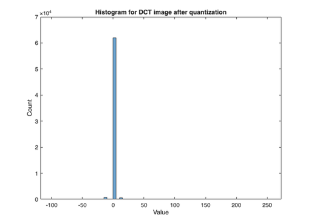

```matlab
ieNewGraphWin;
histogram(dctQuant(:),(-100:5:256))
title('Histogram for DCT image after quantization');
xlabel('Value'); ylabel('Count');

xlim([-118 273])
ylim([0 70000])
```

## JPEG decoding

Now we decode the stored quantized JPEG coefficients to get back an image. To do this, we just need to invert the dct transformation. Again, we apply the decoding step to one 8x8 block first to give you an idea of how it works.

```
ans =

    -4    -9   -21     7    36    17     3    34
   -21    22    42    28    41    33    19    23
    23    35   -15   -19    -9   -19    -6    15
     3   -24    -6   -16   -53   -42   -34   -40
   -31   -19    27    23    -5    24    33   -10
   -10    34    44     0   -10    22    18    33
    19     9   -19    -3   -12     8   -36    18
    20   -22   -37     3   -19    10    52    11
```

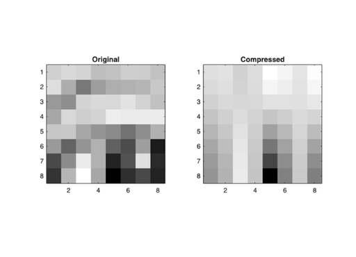

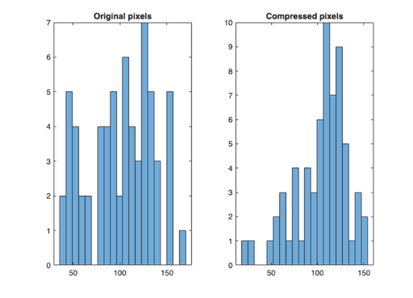

```matlab
block = im(89:96, 105:112);
blockdct = dctQuant(89:96, 105:112);
blockjpeg = idctMatrix*blockdct*idctMatrix';

% Here are the differences between the original and compressed
% block
round(blockjpeg) - block

% And here is a picture of the two blocks
vcNewGraphWin; colormap(linMap)
subplot(1,2,1); imagesc(block), axis image, title('Original')
subplot(1,2,2); imagesc(blockjpeg), axis image, title('Compressed')

% You can see that the reconstructed image intensities are spread
% out again, but not as spread out as the original.
vcNewGraphWin;
subplot(1,2,1); histogram(block(:),20); title('Original pixels')
subplot(1,2,2); histogram(blockjpeg(:),20); title('Compressed pixels')

% If we use the IDCT function in Matlab, the results should be
% the same:
% c = [ 1/sqrt(2) 1 1 1 1 1 1 1 ];
% blockjpeg1 = idct((blockdct*inv(diag(c))*8)');
% blockjpegm = idct((blockjpeg1*inv(diag(c))*8)');
% max(abs(blockjpegm(:) - blockjpeg(:)))
```

## Decode the whole image

```matlab
imjpeg = zeros(size(im));
for i=1:8:size(im,1)
  for j=1:8:size(im,2)
    block = dctQuant(i:i+7, j:j+7);
    imjpeg(i:i+7, j:j+7) = idctMatrix*block*idctMatrix';
  end
end
```

The result of inverse DCT transform is not guarranteed to be within the [0 255] range, so we truncate it.

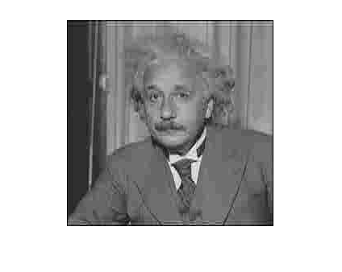

```matlab
imjpeg = round(truncate(imjpeg, 0, 255));

% Now, let's see how well we did.
ieNewGraphWin;
imshow(imjpeg, gray(256));
```

We can repeat this whole set of operations using this function we wrote, jpegCompress, but with a quality factor that makes the artifacts very visible.

```
q1 =

    27    18    20    23    20    17    27    23
    22    23    30    28    27    32    40    67
    43    40    37    37    40    82    58    62
    48    67    97    85   102   100    95    85
    93    92   107   120   153   130   107   113
   145   115    92    93   133   182   135   145
   158   163   172   173   172   103   128   188
   202   187   167   200   153   168   172   165


q1 =

    27    18    20    23    20    17    27    23
    22    23    30    28    27    32    40    67
    43    40    37    37    40    82    58    62
    48    67    97    85   102   100    95    85
    93    92   107   120   153   130   107   113
   145   115    92    93   133   182   135   145
   158   163   172   173   172   103   128   188
   202   187   167   200   153   168   172   165
```

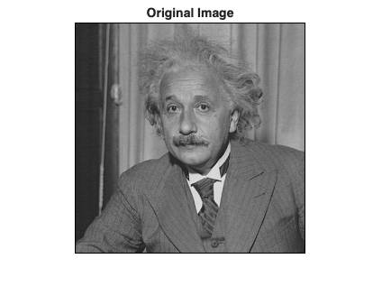

[figure not shown]

[figure not shown]

```matlab
ieNewGraphWin;
Q_factor = 30;
q1 = jpeg_qtables(Q_factor,1)
imjpeg2 = jpegCompress(im, q1);
imjpeg2 = truncate(imjpeg2, 0, 255);
imshow(imjpeg2, gray(256));
close all;

ieNewGraphWin;
imshow(im,gray(256));
title('Original Image')

Q_factor = 30;
q1 = jpeg_qtables(Q_factor,1)
imjpeg2 = jpegCompress(im, q1);
imjpeg2 = truncate(imjpeg2, 0, 255);
figure(2);
imshow(imjpeg2, gray(256));
title('First image')

imjpeg2 = jpegCompress(imjpeg2, q1);
imjpeg2 = truncate(imjpeg2, 0, 255);
ieNewGraphWin;
imshow(imjpeg2, gray(256));
title('Second image')
```

## Thought questions

Note: You do not need to answer these (several are already in your homework quiz.)

```matlab
% Question 1: JPEG COMPRESSION OF GRAYSCALE IMAGE
%
% a) Describe the initial steps (the steps prior to quantization) in the
% JPEG-DCT computation in terms of convolution followed by sampling.
%
% b) At what point is information lost in the JPEG-DCT computation?
%
% c) Why is it better to quantize the JPEG-DCT coefficients rather than
% the intensities of individual pixels?
%
% d) Suppose you use a JPEG-DCT compressor to compress an image
% (yielding image a); then you uncompress the image and compress it
% again using the same compressor and compression settings (yielding
% image b). How will the two compressed images (a and b) compare?  Explain.
%
% e) What are the main visual artifacts present in JPEG-DCT compressed
% grayscale image?  What types of images will display artifacting most
% visibly?
%
% Question 2:
%
% Read the einstein.mat image, and compress it using JPEG quantization
% levels of 75, 50, 25, and 0.  You may want to use the imread and imwrite
% functions to accomplish this.  Normalize all images to have intensities
% from 0 to 1 (as opposed to 0 to 255).
%
% a) Submit the squared-error image for q=25.
%
% b) Describe where the error image has the highest values.  Does this
% agree with your understanding of the JPEG-DCT algorithm?
%
% c) For each compressed image, compute the mean squared error and plot the
% error vs. quantization factor. [You may obtain data for more quantization
% settings if you like, but this is not required.]
%
% d) For each error image, compute the 95th percentile error point.  If
% your error image is called errorim, you can find this value as follows:
%
%    serr = sort(errorim(:)); % sort the error values
%    error95 = serr( floor(0.95 * length(serr)) ); % get the 95th percentile
%
% Also plot error vs quantization factor for this method.
%
% e) If you were evaluating image quality for this image, which method
% (c) or (d) would you use?  Describe why you would use this method.
```

[Published with MATLAB® R2025b](https://www.mathworks.com/products/matlab/)